# YouTube Comment Mining & Text Analysis

Gerhard Williams

# Gathering Text Data Using the YouTube API & Data Analysis Project

This is an R Markdown document that will be used to document the process of this project.

In this project we will go through the steps of gathering the YouTube data, cleaning and transforming the data, exploratory data analysis and finally a clustering analysis.

### Loading Initial Packages

```r
library(tuber)
#library(xlsx)
library(stringr)
library(dplyr)
library(factoextra)
library(ggiraph)
```

### Connecting with YouTube API through Google Account

- Get the client id and client secret from Google account.
- Authorization to access the YouTube API.

```r
yt_oauth(clientid1, clientsecret1, token="")
```

##### The Following pops-up for authorization to access my Google Account’s API Project

- After accepting to use my unverified API project app, enter the authorization code from my google account

Use a local file (‘.httr-oauth’), to cache OAuth access credentials between R sessions?

1: Yes 2: No

Selection: 1 Adding .httr-oauth to .gitignore httpuv not installed, defaulting to out-of-band authentication Enter authorization code: XXXXXXXXXXXXXXXXXXXXXXXXXXXXXXXXXXXXXXXXXXX

#### Use get_all_comments function to get comments from YT video ‘Armin van Buuren live at Ultra Music Festival Miami 2019 (ASOT Stage)’

https://www.youtube.com/watch?v=xr40tgMaD1k

```r
#### Get All Comments from Armin Van Buuren's Live at Ultra Music Festival Miami 2019 ####
# comments come in as a data frame
comments1 <- get_all_comments("xr40tgMaD1k")
```

```
## Auto-refreshing stale OAuth token.
```

- Take a peak at the data and its structure.

```r
head(comments1)
```

```
##       videoId
## 1 xr40tgMaD1k
## 2 xr40tgMaD1k
## 3 xr40tgMaD1k
## 4 xr40tgMaD1k
## 5 xr40tgMaD1k
## 6 xr40tgMaD1k
##                                                                                                                                                                                                                                                                                                  textDisp…
## 1                                                                                                                Eric Prydz was unable to be present for his performance at the ASOT Stage due to an acute medical condition.. <br />Therefore, I played an extended 3,5 hour set. Hope you like it ☺
## 2                                                                                                                                                                                                       I have a question whethrr he gets his inspiration from the gods 🤷‍♂️
## 3 Армин-номер один, без вариантов. Легенда edm....armin you the Best!
## 4                                                                                                                                                                                   ad in the middle fo the video :(. i dont mind ads but please in your live performances put them only on end or beggin…
## 5                                                                                                                                                                                                                                                               Beuatiful set  armim 100%., minute 2,48 s…
## 6                                                                                                                                                                                                                                                                             Pure freaking GoLd🎼
##                                                                                                                                                                                                                                                                                                 textOrigi…
```

[output cut: 41 more lines]

```r
str(comments1)
```

```
## 'data.frame':    1546 obs. of  15 variables:
##  $ videoId              : chr  "xr40tgMaD1k" "xr40tgMaD1k" "xr40tgMaD1k" "xr40tgMaD1k" ...
##  $ textDisplay          : chr  "Eric Prydz was unable to be present for his performance at the ASOT Stage due to an acute medical condition.. <"| __truncated__ "I have a question whethrr he gets his inspiration from the gods 🤷‍♂️" "Армин-номер оди<U+04"| __truncated__ "ad in the middle fo the vid…
##  $ textOriginal         : chr  "Eric Prydz was unable to be present for his performance at the ASOT Stage due to an acute medical condition.. \"| __truncated__ "I have a question whethrr he gets his inspiration from the gods 🤷‍♂️" "Армин-номер оди<U+04"| __truncated__ "ad in the middle fo the vid…
##  $ authorDisplayName    : chr  "Armin van Buuren" "Duke Skywalker" "Fedor Sivashh" "Useless Channel" ...
##  $ authorProfileImageUrl: chr  "https://yt3.ggpht.com/a/AATXAJxhAw1BrmnetrKWriH1SAS1fNCCmIX7vfCwFn0ZOA=s48-c-k-c0xffffffff-no-rj-mo" "https://yt3.ggpht.com/a/AATXAJxzrQgPj-NwQ0_rbTBxYTt04OdRuE3ZL2ijyA=s48-c-k-c0xffffffff-no-rj-mo" "https://yt3.ggpht.com/a/AATXAJzXbwaJ5LGGUvY_ozkwVoJgN1qobMBsL9fSM…
##  $ authorChannelUrl     : chr  "http://www.youtube.com/channel/UCu5jfQcpRLm9xhmlSd5S8xw" "http://www.youtube.com/channel/UC2JpNoRfRdSFG_kcoXwuwUw" "http://www.youtube.com/channel/UC6SB7guV3Rq0JAWSwjCc_AQ" "http://www.youtube.com/channel/UCx-3Dd6AL2hWSfudt7Be6JQ" ...
##  $ authorChannelId.value: chr  "UCu5jfQcpRLm9xhmlSd5S8xw" "UC2JpNoRfRdSFG_kcoXwuwUw" "UC6SB7guV3Rq0JAWSwjCc_AQ" "UCx-3Dd6AL2hWSfudt7Be6JQ" ...
##  $ canRate              : chr  "TRUE" "TRUE" "TRUE" "TRUE" ...
##  $ viewerRating         : chr  "none" "none" "none" "none" ...
##  $ likeCount            : chr  "2192" "0" "0" "0" ...
##  $ publishedAt          : chr  "2019-04-02T09:09:41Z" "2020-08-24T16:38:30Z" "2020-08-23T13:28:55Z" "2020-08-21T21:03:23Z" ...
##  $ updatedAt            : chr  "2019-04-02T09:11:09Z" "2020-08-24T16:38:30Z" "2020-08-23T13:28:55Z" "2020-08-21T21:03:23Z" ...
##  $ id                   : chr  "UgxSsr_-W4alFQRK--54AaABAg" "Ugxhecmd_t3tkLTxybl4AaABAg" "UgyPo6pDXibdFQRZhnN4AaABAg" "UgwKLC5KZmyKi6W19hR4AaABAg" ...
##  $ parentId             : chr  NA NA NA NA ...
##  $ moderationStatus     : logi  NA NA NA NA NA NA ...
```

### Creating a Word Cloud of the Comments

```r
library("tm")
```

```r
library("wordcloud")
library("RColorBrewer")
```

#### Load the YT video comments (textDisplay) in as a Corpus

“A text corpus is a large and unstructured set of texts (nowadays usually electronically stored and processed) used to do statistical analysis and hypothesis testing, checking occurrences or validating linguistic rules within a specific language territory.” - https://guides.library.uq.edu.au/research-techniques/text-mining-analysis/language-corpora

```r
##### Load the YT video comments (textDisplay) in as a Corpus ####

docs <- Corpus(VectorSource(comments1$textDisplay))
```

#### Clean up the doc texts/Text Transformation - stopwords, numbers, etc.

```r
#### Clean up the doc texts/Text Transformation - stopwords, numbers, etc. ####
# Remove numbers
docs <- tm_map(docs, removeNumbers)

# Convert the text to lower case
##docs <- tm_map(docs, content_transformer(tolower)) - due to non-english alphabet text this causes problems

docs <- tm_map(docs, removeWords, stopwords("english"))

docs <- tm_map(docs, removePunctuation)

# specify your stopwords as a character vector
docs <- tm_map(docs, removeWords, c("amp", "the"))

# Eliminate extra white spaces
docs <- tm_map(docs, stripWhitespace)
```

#### Create Term Document Matrix

```r
######## Term Document Matrix #####

dtm <- TermDocumentMatrix(docs)
m <- as.matrix(dtm)
v <- sort(rowSums(m),decreasing=TRUE)
d <- data.frame(word = names(v),freq=v)
head(d, 10)
```

```
##                                                                                    word
## hrefhttpswwwyoutubecomwatchvxrtgmadkampthms hrefhttpswwwyoutubecomwatchvxrtgmadkampthms
## armin                                                                             armin
## van                                                                                 van
## buuren                                                                           buuren
## set                                                                                 set
## hrefhttpswwwyoutubecomwatchvxrtgmadkamptms   hrefhttpswwwyoutubecomwatchvxrtgmadkamptms
## the                                                                                 the
## trance                                                                           trance
## remix                                                                             remix
## best                                                                               best
##                                             freq
## hrefhttpswwwyoutubecomwatchvxrtgmadkampthms  983
## armin                                        749
## van                                          521
## buuren                                       353
## set                                          348
## hrefhttpswwwyoutubecomwatchvxrtgmadkamptms   340
## the                                          294
## trance                                       223
## remix                                        213
## best                                         193
```

```r
#### manually remove some links that were spammed in comments ####
d <- subset(d, word!=c("hrefhttpswwwyoutubecomwatchvxrtgmadkampthms","hrefhttpswwwyoutubecomwatchvxrtgmadkamptms"))

#### remove rows with link comments using subset() & grepl() ####

d <- subset(d, grepl("href", d$word) !=TRUE)
```

#### Plotting a Word Cloud from the YT Comments

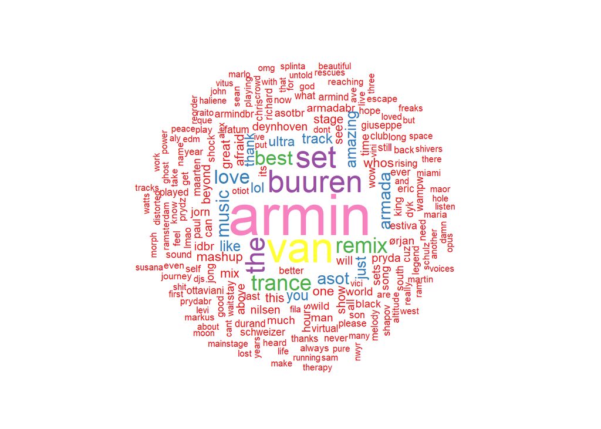

```r
#### Word CLoud ####
set.seed(1776)
wordcloud(words = d$word, freq = d$freq, min.freq = 5,
          max.words=200, random.order=FALSE, rot.per=0.35,
          colors=brewer.pal(8, "Set1"))
```

### Word Frequency Plot

- Load in packages.

```r
#### Word Frequency Plot ####
library(ggplot2)
library(ggiraph)
```

- Creating the plot

```r
#create tooltip
tooltip_css <- "background-color:gray;color:white;font-style:italic;padding:10px;border-radius:10px 20px 10px 20px;font-family:Trebuchet MS"

#select top 25
top25d <- head(d, 25)

#tooltip
top25d$tooltipwords <- paste0("Word: ",top25d$word, "<br/>", "Frequency: ", top25d$freq)

Arminbar <- ggplot(top25d, aes(reorder(x = word, +freq), y = freq, fill=word, tooltip=tooltipwords, data_id = word)) +
  geom_col_interactive() +
  coord_flip() +
  ggtitle("Word Frequency in YouTube Comments of \n Armin van Buuren's 2019 Ultra Music Festival Set", subtitle = "Top 25 Most Frequent Words") +
  xlab("Words") +
  ylab("Frequency")

ggiraph(code = print(Arminbar), width_svg = 8, height_svg = 4, tooltip_extra_css = tooltip_css, hover_css = "cursor:pointer;fill:red;r:3pt;")
```

[interactive chart not shown]

#### Find Associations/Correlations with the Words (Armin, Love, & Trance)

- Load in package and create list of source words to be correlated with

```r
#### Find Associations ####
library(tm) #load package for findAssocs function

#### list of correlation source words ####
corterms <- c("armin","love","trance")

print(corterms)
```

```
## [1] "armin"  "love"   "trance"
```

- Create function that creates a dataframe with words associated with Armin, Love & Trance at a level higher than 0.30

```r
#### create function to dataframe with correlations for each selected word ####
corrfun <- function(x) {
  corrdf1 <- NULL
  for(i in x) {
    corrdf <- rbind((as.data.frame(findAssocs(dtm, terms = i, corlimit = 0.3))))
    corrdf$SourceWord <- i
    colnames(corrdf)[1] <- "Correlation.Percent"
    colnames(corrdf)[2] <- "Correlation.Source.Word"
    ## make rownames into a column with the secondary correlated word
    corrdf <- cbind(rownames(corrdf), data.frame(corrdf, row.names=NULL))
    ## take the id column and make it the 'Correlated.Word'
    colnames(corrdf)[1] <- "word"
    corrdf1 <- rbind(corrdf1, corrdf)
    #print(corrdf1)
  }
  return(corrdf1)
}
```

- Apply the function to the list of source words

```r
## apply the function to the list of corterms
corrfundf <- corrfun(corterms)

head(corrfundf)
```

```
##     word Correlation.Percent Correlation.Source.Word
## 1 buuren                0.94                   armin
## 2    van                0.94                   armin
## 3  above                0.94                   armin
## 4 nilsen                0.94                   armin
## 5  wampw                0.94                   armin
## 6 beyond                0.93                   armin
```

### Cleaning the new correlation dataframe

```r
#### cleaning the corrfundf dataframe ####

#convert Correlation.Word from Factors to Characters
corrfundf$word <- as.character(corrfundf$word)

#remove more href links
corrfundf <- subset(corrfundf, grepl("href.", corrfundf$word) !=TRUE)
corrfundf <- subset(corrfundf, grepl("-", corrfundf$word) !=TRUE)
corrfundf <- subset(corrfundf, grepl("href.", corrfundf$word) !=TRUE)

## remove non-alpha numeric symbols and convert non-english alphabet letters to english letters
library(stringr)
corrfundf$word <- str_replace_all(corrfundf$word, "[^[:alnum:]]", "")
corrfundf$word <- str_replace_all(corrfundf$word, "[^a-zA-Z0-9]", "")

corrfundf$word <- iconv(corrfundf$word, from = 'UTF-8', to = 'ASCII//TRANSLIT')

# remove the empty rows
corrfundf <- corrfundf %>% filter(word != "")

head(corrfundf)
```

```
##     word Correlation.Percent Correlation.Source.Word
## 1 buuren                0.94                   armin
## 2    van                0.94                   armin
## 3  above                0.94                   armin
## 4 nilsen                0.94                   armin
## 5  wampw                0.94                   armin
## 6 beyond                0.93                   armin
```

- Merge the correlation dataframe with the main YT comment word list dataframe to attach the frequency column

```r
##### Merge 'd' dataframe and corrfunddf by word to attach freq variable ####

corrfundf <- merge(d, corrfundf, by.x = "word", by.y = "word")
# turn source word into factor
corrfundf$Correlation.Source.Word <- as.factor(corrfundf$Correlation.Source.Word)

head(corrfundf)
```

```
##     word freq Correlation.Percent Correlation.Source.Word
## 1  about   27                0.60                    love
## 2  about   27                0.86                   armin
## 3  above   69                0.66                    love
## 4  above   69                0.94                   armin
## 5 afraid   85                0.83                   armin
## 6 afraid   85                0.62                    love
```

### Scatter Plot of Word Frequency and Source Word Correlation Percent (Source Words: Armin, Trance, Love)

```r
#### create ggplot scatterplot freq~correlation percent with Source.Word as factor ####

#tooltip
corrfundf$tooltipscatwords <- paste0("Word: ",corrfundf$word, "<br/>", "Frequency: ", corrfundf$freq,
"<br/>", "Correlation with ", "<b>", corrfundf$Correlation.Source.Word, "</b>", ": ", corrfundf$Correlation.Percent)

scatplot <- ggplot(corrfundf, aes(x=Correlation.Percent, y=freq, color=Correlation.Source.Word, tooltip=tooltipscatwords, data_id = tooltipscatwords)) +
  geom_point_interactive() +
  scale_y_log10() +
  ggtitle("Word Frequency & Correlation with Source Words \n Armin van Buuren's 2019 Ultra Music Festival Set", subtitle = "Words with at least a 30% Correlation to the Source Word") +
  xlab("Correlation with Source Word") +
  ylab("Frequency (log 10)")

ggiraph(code = print(scatplot), width_svg = 8, height_svg = 4, tooltip_extra_css = tooltip_css, hover_css = "cursor:pointer;fill:red;r:3pt;")
```

[interactive chart not shown]

### Barplots of Frequency & Correlation - Facet Grid by Source Word

```r
#### facet-grid/wrap of barplots frequency & correlation ####

#tooltip
corrfundf$tooltipscatwords <- paste0("Word: ",corrfundf$word, "<br/>", "Frequency: ", corrfundf$freq,
                                     "<br/>", "Correlation with ", "<b>", corrfundf$Correlation.Source.Word, "</b>", ": ", corrfundf$Correlation.Percent)


Arminbarfreqfacet <- ggplot(corrfundf, aes(reorder(x = word, +freq), y = freq, group = Correlation.Source.Word, tooltip=tooltipscatwords, data_id = tooltipscatwords)) +
  geom_col_interactive(aes(fill = Correlation.Source.Word)) +
  coord_flip() +
  ggtitle("Word Frequency in YouTube Comments of \n Armin van Buuren's 2019 Ultra Music Festival Set", subtitle = "All Words by Correlated Source Word") +
  xlab("Words") +
  ylab("Frequency") +
  scale_y_log10() +
  facet_grid(. ~ Correlation.Source.Word)

ggiraph(code = print(Arminbarfreqfacet), width_svg = 8, height_svg = 4, tooltip_extra_css = tooltip_css, hover_css = "cursor:pointer;fill:red;r:3pt;")
```

[interactive chart not shown]

```r
Arminbarcorrfacet <- ggplot(corrfundf, aes(reorder(x = word, +Correlation.Percent), y = Correlation.Percent, group = Correlation.Source.Word, tooltip=tooltipscatwords, data_id = tooltipscatwords)) +
  geom_col_interactive(aes(fill = Correlation.Source.Word)) +
  coord_flip() +
  ggtitle("Correlation of Words in YouTube Comments of \n Armin van Buuren's 2019 Ultra Music Festival Set", subtitle = "All Words by Correlated Source Word") +
  xlab("Words") +
  ylab("Correlation") +
  #scale_y_log10() +
  theme(axis.text.x = element_text_interactive(size=10)) +
  facet_grid(Correlation.Source.Word ~ .)

ggiraph(code = print(Arminbarcorrfacet), width_svg = 8, height_svg = 4, tooltip_extra_css = tooltip_css, hover_css = "cursor:pointer;fill:red;r:3pt;")
```

[interactive chart not shown]

## Cluster Analysis for Words Correlated with “Armin”

```r
#cluster by armin correlation word - create new df with only armin assoc. words
arminclust <- subset(corrfundf, corrfundf$Correlation.Source.Word == "armin")

#select relevant columns
ytcorrfreqarmin <- subset(arminclust, select = c("word", "freq","Correlation.Percent"))

head(ytcorrfreqarmin)
```

```
##           word freq Correlation.Percent
## 2        about   27                0.86
## 4        above   69                0.94
## 5       afraid   85                0.83
## 8    afterdark    6                0.49
## 9  afterdarkbr   11                0.67
## 12         air   24                0.91
```

```r
#remove duplicates in word column
ytcorrfreqarmin <- subset(ytcorrfreqarmin, !duplicated(ytcorrfreqarmin$word), TRUE)

head(ytcorrfreqarmin)
```

```
##           word freq Correlation.Percent
## 2        about   27                0.86
## 4        above   69                0.94
## 5       afraid   85                0.83
## 8    afterdark    6                0.49
## 9  afterdarkbr   11                0.67
## 12         air   24                0.91
```

```r
#make word column the rownames column - data frame
ytcorrfreqarmindf <- data.frame(ytcorrfreqarmin, row.names = 1)

#scale the df - standardizes/creates a center for each column
ytcorrfreqarmindf <- scale(ytcorrfreqarmindf)
head(ytcorrfreqarmindf)
```

```
##                   freq Correlation.Percent
## about       -0.1457484           0.4758868
## above        0.7524881           0.8999032
## afraid       1.0946735           0.3168806
## afterdark   -0.5948667          -1.4851893
## afterdarkbr -0.4879338          -0.5311523
## air         -0.2099082           0.7408971
```

```r
#create alt scaled dataframe for plotting
ytcorrfreqarmindf2 <- scale(ytcorrfreqarmindf)
ytcorrfreqarmindf2 <- cbind(rownames(ytcorrfreqarmindf2), data.frame(ytcorrfreqarmindf2, row.names=NULL))
colnames(ytcorrfreqarmindf2)[1] <- "word"
```

### Scatter Plot of Scaled Dataframe

```r
#### create ggplot scatterplot of the scaled DF freq~correlation percent with Source.Word as factor ####

#tooltip
ytcorrfreqarmindf2$tooltipscatwords <- paste0("Word: ", "<b>", ytcorrfreqarmindf2$word, "</b>", "<br/>", "Scaled Frequency: ", "<b>", ytcorrfreqarmindf2$freq, "</b>",
                                           "<br/>", "Scaled Correlation with Armin: ", "<b>", ytcorrfreqarmindf2$Correlation.Percent, "</b>")

ytarminscat2 <- ggplot(ytcorrfreqarmindf2, aes(x=freq, y=Correlation.Percent, tooltip=tooltipscatwords, data_id = tooltipscatwords)) +
  geom_point_interactive() +
  scale_x_log10() +
  ggtitle(" Scaled Word Frequency & Correlation with Armin Scatter Plot \n Armin van Buuren's 2019 Ultra Music Festival Set", subtitle = "Words with at least a 30% Correlation to the Source Word") +
  ylab("Scaled Correlation Percent") +
  xlab("Scaled Frequency (log 10)")

ggiraph(code = print(ytarminscat2), width_svg = 8, height_svg = 4, tooltip_extra_css = tooltip_css, hover_css = "cursor:pointer;fill:red;r:3pt;")
```

[interactive chart not shown]

### Finding the Optimal Amount of Clusters

- Will use the K-Means/“Naive K-Means” clustering algorithm
- Will use Euclidean Distance (default in fviz_nbclust function) because the matrix/dataframe is only two columns with every row filled - Manhattan Distance would be considered if the data had more dimensions.

#### KMEANS & Elbow Method

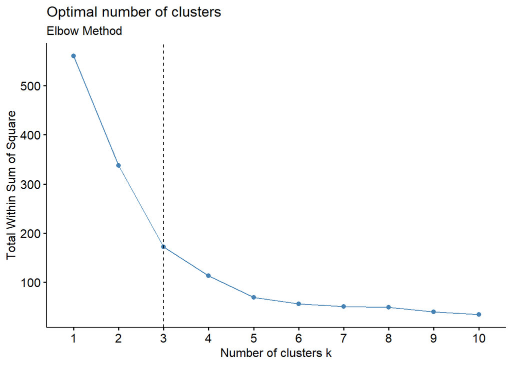

```r
#### Elbow method ####
set.seed(1776)
fviz_nbclust(ytcorrfreqarmindf, kmeans, method = "wss") +
  geom_vline(xintercept = 3, linetype = 2)+
  labs(subtitle = "Elbow Method")
```

#### Silhouette Method

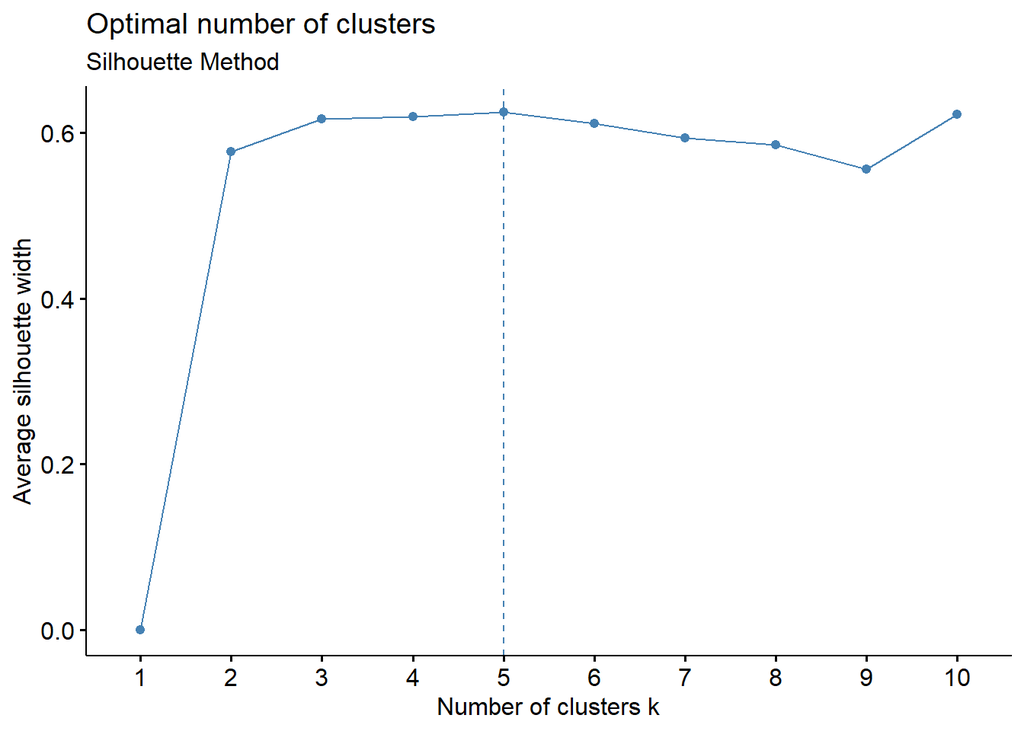

```r
#### Silhouette method ####
set.seed(1776)
fviz_nbclust(ytcorrfreqarmindf, kmeans, method = "silhouette")+
  labs(subtitle = "Silhouette Method")
```

```r
#silhouette method suggests using 5 clusters - use highest average silhouette width
```

#### Gap Stat Method

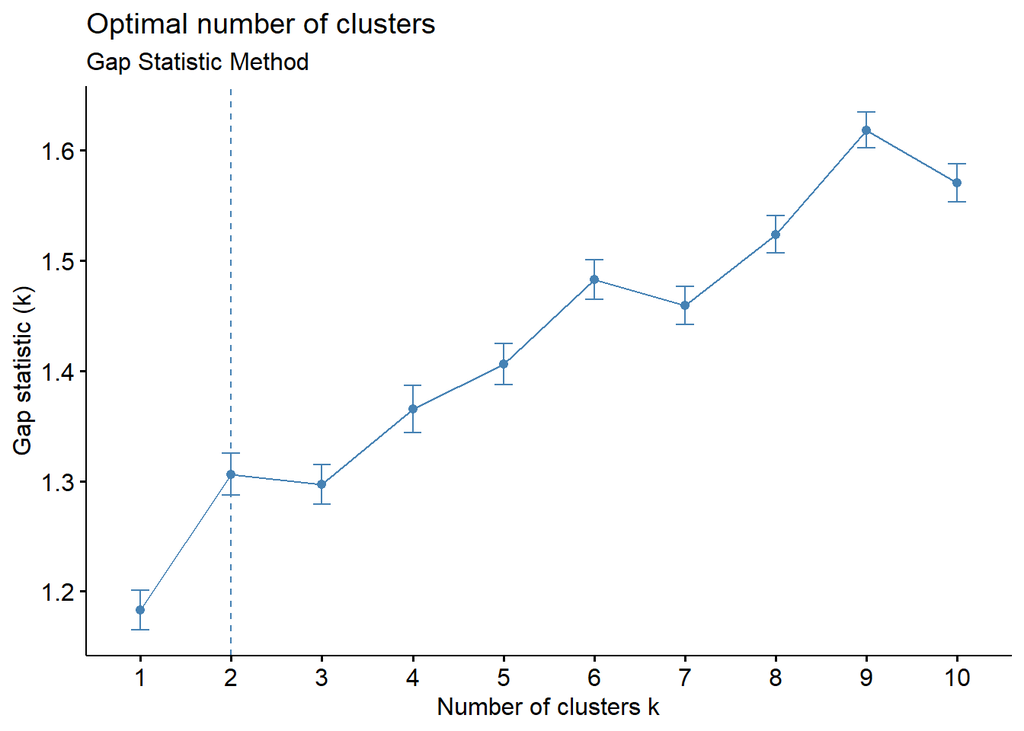

```r
#### Gap Stat Method ####
set.seed(1776)
fviz_nbclust(ytcorrfreqarmindf, kmeans, nstart = 25,  method = "gap_stat", nboot = 100)+
  labs(subtitle = "Gap Statistic Method")
```

- The gap statistic compares the total intracluster variation for different values of k with their expected values under null reference distribution of the data (i.e. a distribution with no obvious clustering). - UC Davis Business Analytics - https://uc-r.github.io/kmeans_clustering
- The first local maximum will be chosen as the optimal number of clusters.

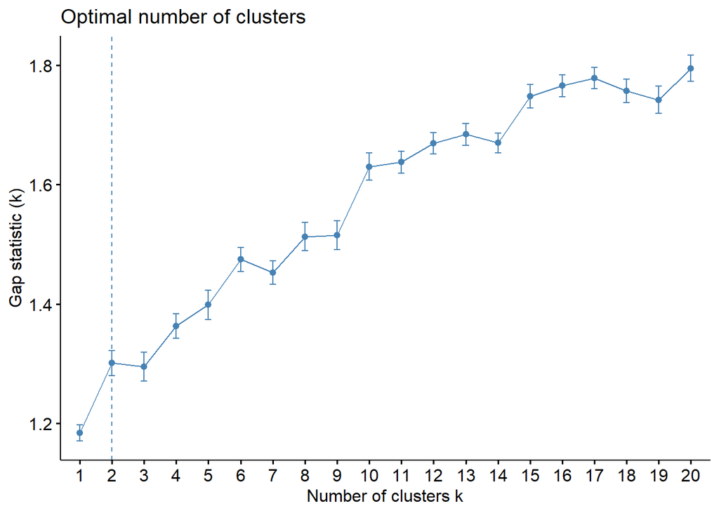

```r
#### Gap Stat Method 2nd####
library(cluster)
set.seed(1776)
gap_stat <- clusGap(ytcorrfreqarmindf, FUN = kmeans, nstart=25, K.max = 20, B = 10)

fviz_gap_stat(gap_stat)
```

```r
gapDF <- as.data.frame(gap_stat$Tab)

gapplot <- ggplot(gapDF, aes(x=1:nrow(gapDF))) +
  geom_line(aes(y=logW, color="logw - Observed")) +
  geom_point_interactive(aes(y=logW, color="logw - Observed",tooltip=paste0("Gap: ", gap), data.id=rownames(gapDF))) +
  geom_line(aes(y=E.logW, color="E.logw - Expected")) +
  geom_point_interactive(aes(y=E.logW, color="E.logw - Expected",tooltip=paste0("Gap: ",gap), data.id=rownames(gapDF))) +
  labs(x="Number of Clusters") +
  scale_color_manual("",
                     breaks = c("logw - Observed", "E.logw - Expected"),
                     values = c("logw - Observed" = "blue", "E.logw - Expected" = "green"))

ggiraph(code = print(gapplot), width_svg = 8, height_svg = 4, tooltip_extra_css = tooltip_css, hover_css = "cursor:pointer;fill:red;r:3pt;")
```

[interactive chart not shown]

* When the number of clusters is increased, the gap statistic has higher local maximums. This suggests that there are many small subclusters within the 2 larger separated clusters.

#### Lets look again at the scatterplot of the scaled data, except without the log10 transformation.

```r
simpscat <- ggplot(ytcorrfreqarmindf2, aes(x=freq, y=Correlation.Percent, tooltip=tooltipscatwords, data_id = tooltipscatwords)) +
  geom_point_interactive() +
  ggtitle(" Scaled Word Frequency & Correlation with Armin Scatter Plot \n Armin van Buuren's 2019 Ultra Music Festival Set", subtitle = "Words with at least a 30% Correlation to the Source Word") +
  ylab("Scaled Correlation Percent") +
  xlab("Scaled Frequency")

ggiraph(code = print(simpscat), width_svg = 8, height_svg = 4, tooltip_extra_css = tooltip_css, hover_css = "cursor:pointer;fill:red;r:3pt;")
```

[interactive chart not shown]

- The increase in the Gap Statistic as the number of clusters increases may be due to the large scale of the Frequency (x-axis) and how most points are distributed widely amongst the y-axis but concentrated on the x-axis.

### Partitioning into 4 Clusters

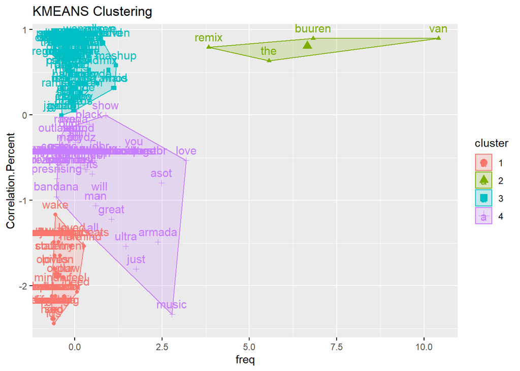

```r
#### create the kmeans clustering visual ####
set.seed(1776)
res.km <- eclust(ytcorrfreqarmindf, "kmeans", k.max = 10, k=4, nstart = 55, graph=TRUE, seed=1776)
```

```r
#fviz_cluster(res.km, ytcorrfreqarmindf)
```

#### Merge Clustering Results to Original Dataframe - Preparation for CSV Download

```r
#### assigning the clusters to the data for export to csv ####

#put cluster info into dataframe
armin.w.clust <- as.data.frame(res.km$cluster)

#turn the index column into a column of the df
armin.w.clust <- cbind(rownames(armin.w.clust), data.frame(armin.w.clust, row.names=NULL))

## take the id column and make it the 'Correlated.Word'
colnames(armin.w.clust)[1] <- "word"

## merge the original dataframe w/ freq & correlation % with the cluster df
armin.w.clust.df <- merge(ytcorrfreqarmin, armin.w.clust, by.x = "word", by.y = "word")
## rename the 4th column to cluster
colnames(armin.w.clust.df)[4] <- "cluster"

## arrange dataframe by cluster
armin.w.clust.df <- armin.w.clust.df %>%
  arrange(cluster)

head(armin.w.clust.df)
```

```
##                word freq Correlation.Percent cluster
## 1         afterdark    6                0.49       1
## 2       anjunabeats   12                0.49       1
## 3 armadaanjunabeats   12                0.49       1
## 4            armind   46                0.48       1
## 5          bayfront    3                0.34       1
## 6           beloved    3                0.37       1
```

```r
## extract to csv file
# write.csv(armin.w.clust.df, 'YouTube.Comment.Armin.Clusters.csv')
```

### Most Liked Comment

```r
library(dplyr)
comments1$likeCount <- as.numeric(comments1$likeCount)
MostLiked <- comments1 %>%
  arrange(desc(comments1$likeCount)) %>%
  head(1)

MostLiked$authorDisplayName
```

```
## [1] "Armin van Buuren"
```

```r
MostLiked$textDisplay
```

```
## [1] "Eric Prydz was unable to be present for his performance at the ASOT Stage due to an acute medical condition.. <br />Therefore, I played an extended 3,5 hour set. Hope you like it ☺"
```

### Credits & Inspiration:

- https://blog.dominodatalab.com/clustering-in-r/
- https://rpkgs.datanovia.com/factoextra/reference/fviz_cluster.html
- https://rstudio-pubs-static.s3.amazonaws.com/375287_5021917f670c435bb0458af333716136.html
- https://uc-r.github.io/kmeans_clustering
- https://afit-r.github.io/kmeans_clustering
- https://rstudio-pubs-static.s3.amazonaws.com/33876_1d7794d9a86647ca90c4f182df93f0e8.html